# Placing Towers in the Game

We need to allow players to try different strategies because tower defense games are strategic in nature. Players should be able to place towers on the map to apply their strategy.

In this chapter, we’ll create the *TowerPlacer* class to manage *Towers* on the map. It prevents *Towers* from overlapping with each other and keeps track of where players can place a *Tower*. For instance, preventing players from placing *Towers* on top of rocks or in an *Enemies*’s walking path.

To solve these problems, we’ll:

- Abstract the game’s world as grid cells
- Use tiles’ indices as metadata
- Snap mouse coordinates to grid cells
- Instance scenes dynamically
- Manage the free cells of a map

The techniques above are the backbone of other nice features. For instance, you could implement a level design tool to allow players to mod your game.

The *TowerPlacer* is a support class and isn’t designed to work on its own. The level class, which we will see next, feeds it with information about the game world and the tower shop class feeds it with the tower it should manage.

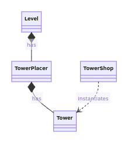

## Using Tilemaps as a Grid

Usually in Godot, we use the *TileMap* node to design the levels of our games. But in our approach, we use the *TileMap*’s features to create a 2D matrix with metadata about our game.

*TileMaps* can define the “resolution” of your grid using the *Cell > Size* property. We use the default 64 by 64 resolution. They also offer useful mapping and cell management methods. We use the `map_to_world()` and `world_to_map()` method to convert world and map coordinates. The `set_cellv()` method changes the ID of a cell so we know if it’s available or not.

Create a new scene with a *TileMap* as the root node and name it *TowerPlacer*. Save the scene as `res://Levels/TowerPlacer/TowerPlacer.tscn`.

This is the grid that will store metadata about cells. We also provide a visual representation of the cells to players. This communicates to the players that we abstracted the game space into a grid.

Let’s create the grid’s visual representation. Add another *TileMap* as a child of the *TowerPlacer* and rename it as *VisualGrid*.

In the *VisualGrid > Tileset* property, create a new *Tileset*. Click on the *Tileset* property slot to prompt the *Tileset Editor* on the bottom of the screen. Drag the `res://grid-cell.svg` image to the left panel. Create a new single tile and enable the grid snap.

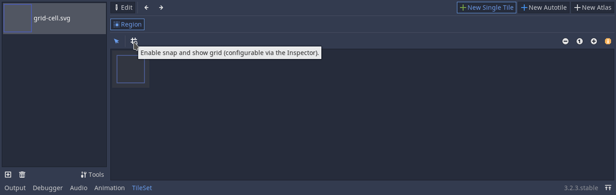

Click and drag to select the whole cell image. When you release the left mouse button, you should have a *Tileset* with a single 64 by 64 tile to draw.

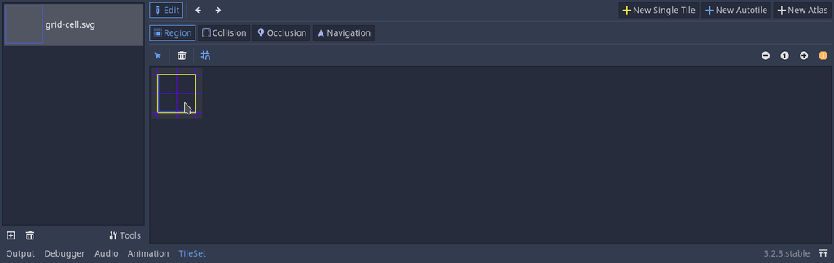

Select the *VisualGrid* node again. Hold CTRL (CMD on *Mac*) and *Shift*-click to draw a rectangle that covers the whole screen.

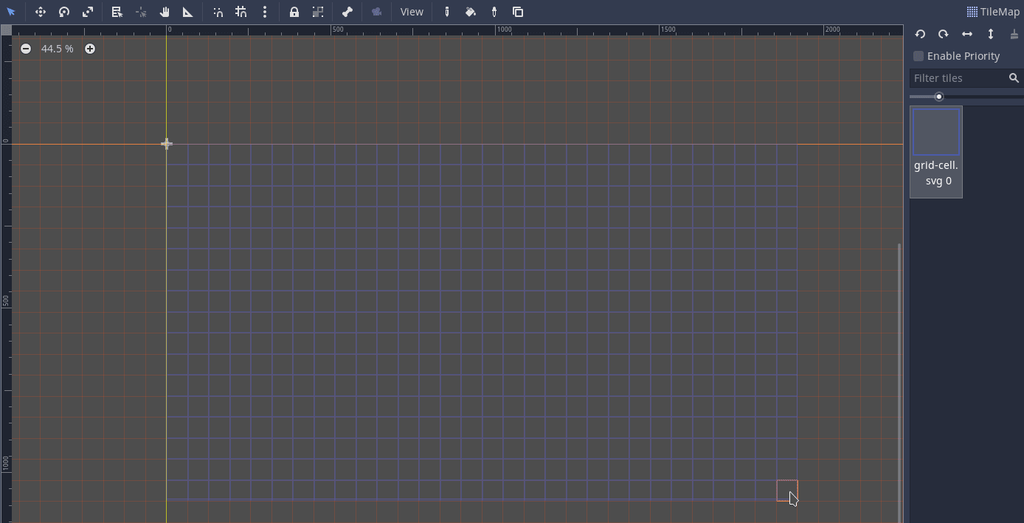

Toggle off the *VisualGrid* visibility because it should only be visible when players are placing towers. We control its visibility through the *TowerPlacer* script.

Attach a new script to the *TowerPlacer* node. Save it together with the scene at `res://Levels/TowerPlacer/TowerPlacer.gd`.

Since the *TowerPlacer* scene is the only scene using it, move the `res://grid-cell.svg` to be inside the same folder.

Now, let’s start coding the *TowerPlacer* behavior!

## Using tile IDs as metadata

The idea behind this approach is to use tile indices to keep track of free spaces in the game world. We use the `0` and `1` indices to represent a free or occupied cell respectively.

```
# The ID of the tiles where players can place a tower.
const AVAILABLE_CELL_ID := 0
# The ID of cells already occupied or obstructed
const INVALID_CELL_ID := 1
```

Since the core responsibility of the *TowerPlacer* is to manage where players can place *Towers*, we create methods to change the current state of a cell.

Let’s start by creating the `set_cell_unplaceable()` method. We use the *TileMap* `set_cellv()` method to change a cell’s ID to `INVALID_CELL_ID`. For that we receive a

[figure not shown]

`Vector2` that represents the cell that will have its ID changed.

We create the `set_cell_placeable()` method to flag that cell as being available again if players decide to sell a *Tower*.

We also create a method that checks if a cell is placeable or not.

```
func set_cell_unplaceable(cell: Vector2) -> void:
    set_cellv(cell, INVALID_CELL_ID)


func set_cell_placeable(cell: Vector2) -> void:
    set_cellv(cell, AVAILABLE_CELL_ID)


func is_cell_placeable(cell: Vector2) -> bool:
    return get_cellv(cell) == AVAILABLE_CELL_ID
```

The *TowerPlacer* itself isn’t aware of which cells it should consider available. Instead, we create a method to allow other classes to pass a list of available cells to the *TowerPlacer*. We run through all these cells using the `set_cell_placeable()` method to set them as placeable cells.

The `setup_available_cells()` receives an array of

[figure not shown]

`Vector2`. Each of these elements represents a cell that the *TowerPlacer* will consider as available.

```
func setup_available_cells(cells_array: PoolVector2Array) -> void:
    for cell in cells_array:
        set_cell_placeable(cell)
```

## Adding new Towers to the world

Now that we know where players can place *Towers* in the game world, it’s time to add *Towers*.

In the *Godot Engine*, we save scenes as “templates” for objects that we can instance in run time. A

[figure not shown]

`PackedScene` is what we call a serialized `SceneTree`. We can instance

[figure not shown]

`PackedScene` during runtime by calling the `instance()` method.

However, our *TowerPlacer* isn’t responsible for that. The *TowerPlacer* should receive an instance of a *Tower* from other classes.

The *TowerPlacer* should always be working with the current tower the player wants to place. When the player decides to place a tower, we add a check to replace the previous tower with the current one.

After receiving an instance, the *TowerPlacer* adds it as its child and handles its placement in the grid.

We don’t want to instance the *Tower* and let it sit in its initial position. We want players to decide where they should stay so the *TowerPlacer* is going to listen to player’s mouse inputs. We also create an `onready` variable to store a reference to the *VisualGrid* so we can toggle its visibility.

```
onready var _visual_grid := $VisualGrid

var _current_tower: Tower

func add_new_tower(tower: Tower) -> void:
    # Remove the current tower to work only with the newest one
    if _current_tower:
        _current_tower.queue_free()

    add_child(tower)
    _current_tower = tower

    set_process_unhandled_input(true)
    _visual_grid.visible = true
```

## Snapping the Tower to map’s cells

We use a *TileMap* to abstract the game space because it’s easier to manage chunks of the game’s world instead of individual pixels. This is one of the reasons why grids are so common in tabletop games.

To make players place the *Towers* in grid steps, we need to snap the *Tower*’s position to the grid. For that, we can use the *TileMap* `world_to_map()` and `map_to_world()` methods based on player’s mouse position. Let’s create a `_snap_tower_to_grid()` method for that snapping.

We store converted coordinates in a member variable to access it across other methods. We can call it `_current_cell`.

Now that we know the cell the mouse is sitting on, we can snap the *Tower*’s position to the cell’s origin using the `map_to_world()` method.

```
var _current_cell := Vector2.ZERO

func _unhandled_input(event: InputEvent) -> void:
    if event is InputEventMouseMotion:
        _snap_tower_to_grid()


func _snap_tower_to_grid() -> void:
    # Converts the mouse's global position to map coordinates
    _current_cell = world_to_map(get_global_mouse_position())

    # Uses the map coordinates to remap the _current_tower position snapping it
    # to the grid cells
    _current_tower.global_position = map_to_world(_current_cell)
```

Let’s change the *Tower*’s modulate property towards red to provide visual feedback when a cell isn’t available. We turn the `modulate` property back to white if the cell is available.

```
func _snap_tower_to_grid() -> void:
    # ...

    if not is_cell_placeable(_current_cell):
        _current_tower.modulate = Color(1, 0.375, 0.375)
    else:
        _current_tower.modulate = Color.white
```

We can also snap the current tower to the grid as soon as the *TowerPlacer* adds it as its child. In the `add_new_tower()` method, call the `_snap_tower_to_grid()` method at the end. This will prevent the *Tower* from sitting in its original position if the player doesn’t move the mouse.

```
func add_new_tower(tower: Tower) -> void:
    # ...

    _snap_tower_to_grid()
```

We may run into errors if we don’t turn off the `_unhandled_input()` process in the `_ready()` callback. This is because there won’t be anything to snap.

```
func _ready() -> void:
    set_process_unhandled_input(false)
```

## Placing Towers on the map

With the snapping in place, we can now think about how players actually place *Towers* in the game world. Let’s make it so that the left click prompts the tower placement procedure.

We check if players have pressed the `tower_placement` action in the `_unhandled_input()` process. This is an action we’ve set in the start project. When players press this action we call the `_place_tower()` method which we create now.

```
func _unhandled_input(event: InputEvent) -> void:
    # ...

    if event.is_action_pressed("tower_placement"):
        _place_tower()
```

The first thing we do when the player places a tower is to stop listening to inputs. This prevents the player from moving the *Tower* after its placement. We also hide the *VisualGrid* because there’s no need for it anymore.

```
func _place_tower() -> void:
    set_process_unhandled_input(false)
    _visual_grid.visible = false
```

We have two options when the player tries to place a *Tower* on an occupied cell. We can;

1. Ignore it and give a visual or audio hint that the cell isn’t available
2. Understand that as the player trying to get out of the tower placement context

We choose the second option since we want to add more *Towers* in the future. It will allow players to “cancel” the placement of a specific type of *Tower* and pick a new one instead. Players may also want to save some gold and decide to not place any *Tower* at all.

In any case, we free the `_current_tower` and set it as `null` because it won’t have any use. We also return from the function to prevent executing the remaining procedures.

```
func _place_tower() -> void:
    # ...

    if not is_cell_placeable(_current_cell):
        _current_tower.queue_free()
        _current_tower = null
        return

    # When the player places a *Tower* on a placeable cell, that cell should
    # become unavailable.
    set_cell_unplaceable(_current_cell)
```

The *TowerPlacer* should also notify players they successfully placed a new *Tower*. We create a `tower_placed` signal that notifies the `_current_tower` placement. This allows other classes to access any data they need about the *Tower*, such as its cost.

The *TowerPlacer* should know when players sells a *Tower*, so it can set the cell as available. We connect the *Tower*’s `sold` signal to a `_on_Tower_sold()` callback. After dealing with the placement of the tower, we need to set the `_current_tower` value to `null` to prevent removing towers from the map in the `add_new_tower()` method.

```
signal tower_placed(tower)

func _place_tower() -> void:
    # ...

    emit_signal("tower_placed", _current_tower)
    _current_tower.connect("sold", self, "_on_Tower_sold")
    _current_tower = null
```

We remap the `place` parameter to map coordinates in the `_on_Tower_sold()` method. We do this to get the sold tower’s cell. We can then make it available again.

```
func _on_Tower_sold(_price: int, place: Vector2) -> void:
    set_cell_placeable(world_to_map(place))
```

## Code so far

Note that as we went through the logic of the *TowerPlacer* class, we’ve created member variables, methods, and signals on the go. To make our code look better, we need to reorder everything to match our guidelines. You can find the [GDQuest’s Code Guidelines here](https://www.gdquest.com/docs/guidelines/best-practices/godot-gdscript/).

After formatting the code it should look like this:

`TowerPlacer.gd`

```
# Allows the player to interactively place a tower on the game grid.
# Keeps track of free and occupied cells.
class_name TowerPlacer
extends TileMap

signal tower_placed(tower)

# The ID of the tiles where players can place a tower.
const AVAILABLE_CELL_ID := 0
const INVALID_CELL_ID := 1

onready var _visual_grid := $VisualGrid

var _current_cell := Vector2.ZERO
var _current_tower: Tower


func _ready() -> void:
    set_process_unhandled_input(false)


func _unhandled_input(event: InputEvent) -> void:
    if event is InputEventMouseMotion:
        _snap_tower_to_grid()
    if event.is_action_pressed("tower_placement"):
        _place_tower()


func setup_available_cells(cells_array: PoolVector2Array) -> void:
    for cell in cells_array:
        set_cell_placeable(cell)


func add_new_tower(tower: Tower) -> void:
# Remove the current tower to work only with the newest one
    if _current_tower:
        _current_tower.queue_free()

    add_child(tower)
    _current_tower = tower

    set_process_unhandled_input(true)
    _visual_grid.visible = true

    _snap_tower_to_grid()


func set_cell_unplaceable(cell: Vector2) -> void:
    set_cellv(cell, INVALID_CELL_ID)


func set_cell_placeable(cell: Vector2) -> void:
    set_cellv(cell, AVAILABLE_CELL_ID)


func is_cell_placeable(cell: Vector2) -> bool:
    return get_cellv(cell) == AVAILABLE_CELL_ID


func _place_tower() -> void:
    set_process_unhandled_input(false)
    _visual_grid.visible = false

    if not is_cell_placeable(_current_cell):
        _current_tower.queue_free()
        _current_tower = null
        return
    set_cell_unplaceable(_current_cell)

    emit_signal("tower_placed", _current_tower)
    _current_tower.connect("sold", self, "_on_Tower_sold")
    _current_tower = null


func _snap_tower_to_grid() -> void:
    _current_cell = world_to_map(get_global_mouse_position())
    _current_tower.global_position = map_to_world(_current_cell)
    if not is_cell_placeable(_current_cell):
        _current_tower.modulate = Color(1, 0.375, 0.375)
    else:
        _current_tower.modulate = Color.white


func _on_Tower_sold(_price: int, place: Vector2) -> void:
    set_cell_placeable(world_to_map(place))
```

## Testing the TowerPlacer

Time to test our tower placement mechanism!

The *TowerPlacer* doesn’t work on its own, as we’ve mentioned before. To test it, we create a test procedure in the `_ready()` callback that we must delete after the tests.

The first thing we should do is setup available cells to place *Towers* on. Call the `setup_available_cells()` method passing a list of arbitrary cells we’d like to be available. All other cells are not placeable by default. Note that we don’t use “occupied” in the placement context, because a cell can be free, but unplaceable. For instance, it might be a crater.

```
func _ready() -> void:
    set_process_unhandled_input(false)

    # Begin of test lines, remove them after testing
    setup_available_cells([Vector2(12, 7), Vector2(13, 8), Vector2(14, 9)])
```

To get a *Tower* instance, we create a `tower` variable and set its value to be an instance of the *Tower*

[figure not shown]

`PackedScene`. We use the `load()` built-in method and pass the

[figure not shown]

`PackedScene` path as an argument to load the *Tower*

[figure not shown]

`PackedScene`. We call the `instance()` method on it on the same line.

With a tower to work with, let’s pass it as an argument to the `add_new_tower()` method to prompt the *TowerPlacer* behavior.

```
func _ready() -> void:
    # ...

    var tower = load("res://Objects/Towers/Tower.tscn").instance()
    add_new_tower(tower)
    # End of test lines
```

Let’s add a breakpoint to the first line in `_on_Tower_sold()` callback. This will allow us to test if the *TowerPlacer* makes the cell available again.

Hit the *Play Scene* button and find the cells we’ve set up with the `setup_available_cells()`. Once you find one, place the *Tower* and then click on it to sell it.

[figure not shown]

When Godot prompts the breakpoint, step into it and we should reach the point where the cell has its ID set to `AVAILABLE_CELL_ID` in the `set_cell_placeable()` method.

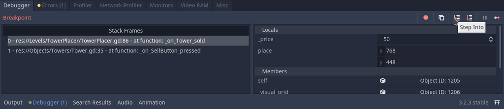